# L09 Themes

Data Visualization (STAT 302)

## Overview

The goal of this lab is to play around with the theme options in `ggplot2`

## Datasets

We’ll be using the `cdc.txt` datasets.

```r
# Load package(s)

# Read in the cdc dataset
cdc <- read_delim(file = "data/cdc.txt", delim = "|") %>%
  mutate(genhlth = factor(genhlth,
    levels = c("excellent", "very good", "good", "fair", "poor"),
    labels = c("Excellent", "Very Good", "Good", "Fair", "Poor")
  ))

# Set seed
set.seed(8221984)

# Selecting a random subset of size 100
cdc_small <- cdc %>% sample_n(100)
```

## Exercises

Complete the following exercises.

### Exercise 1

Use the `cdc_small` dataset to explore several pre-set `ggthemes`. The code below constructs the familiar scatterplot of `weight` by `height` and stores it in `plot_01`. Display `plot_01` to observe the default theme. **Explore/apply, and display at least 7 other pre-set themes** from the `ggplot2` or `ggthemes` package. Don’t worry about making adjustments to the figures under the new themes. Just get a sense of what the themes are doing to the original figure `plot_01`.

```r
# Building plot
plot_01 <- ggplot(data = cdc_small, aes(x = height, y = weight)) +
  geom_point(size = 3, aes(shape = genhlth, color = genhlth)) +
  scale_y_continuous(
    name = "Weight in Pounds",
    limits = c(100, 300),
    breaks = seq(100, 350, 25),
    trans = "log10",
    labels = scales::unit_format(unit = "lbs")
  ) +
  scale_x_continuous(
    name = "Height in Inches",
    limits = c(55, 80),
    breaks = seq(55, 80, 5),
    labels = scales::unit_format(unit = "in", accuracy = 1)
  ) +
  scale_shape_manual(
    name = "General\nHealth?",
    labels = c("Excellent", "Very Good", "Good", "Fair", "Poor"),
    values = c(17, 19, 15, 9, 4)
  ) +
  scale_color_brewer(
    name = "General\nHealth?",
    labels = c("Excellent", "Very Good", "Good", "Fair", "Poor"),
    palette = "Set1"
  ) +
  theme(
    legend.position = c(1, 0),
    legend.justification = c(1, 0)
  ) +
  labs(title = "CDC BRFSS: Weight by Height")
```

### Exercise 2

Using `plot_01` from and the `theme()` function, attempt to construct the ugliest plot possible (example pictured below).

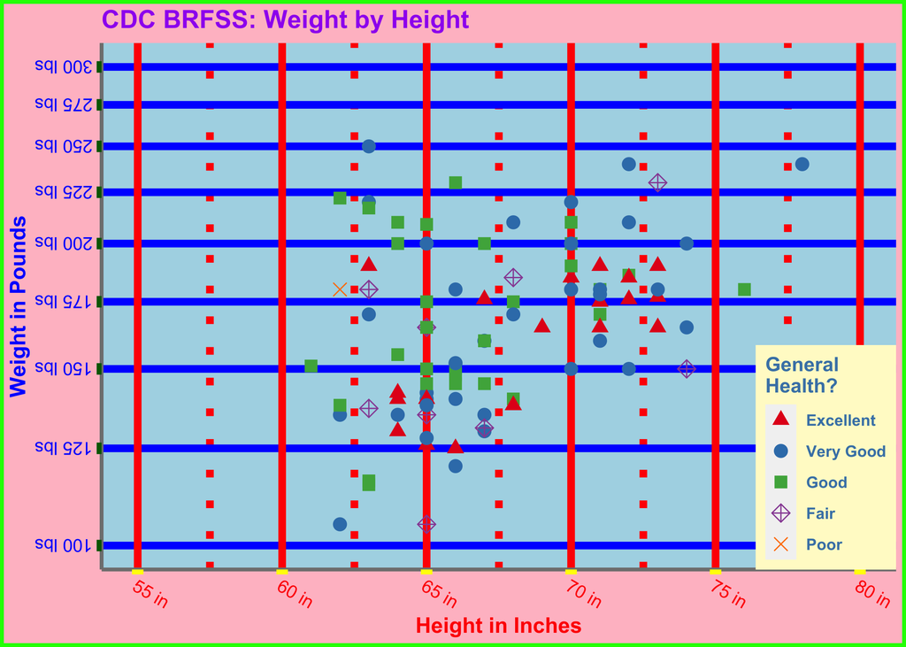

### Exercise 3

Using data from `cdc_small` create a few (at least two) graphics (maybe one scatterplot and one barplot). Style the plots so they follow a “Northwestern” theme. Check out the following webpages to help create the theme:

[Visual Identity](https://www.northwestern.edu/brand/visual-identity/index.html)

- [Web Colors](https://www.northwestern.edu/brand/visual-identity/color/digital-colors.html)
- [Secondary Palette](https://www.northwestern.edu/brand/visual-identity/color/secondary-palette.html)
- [Fonts & Typography](https://www.northwestern.edu/brand/visual-identity/fonts-typography/index.html) — Need to use [substitute fonts](https://www.northwestern.edu/brand/visual-identity/fonts-typography/substitute-fonts.html)